# Clustering Analysis for Mathematics Creativity Assessment project

Zhengzheng Wang, wanzy120

04/02/2022

# 1. Data exploration

```r
set.seed(420)
# load data, assign Student ID column as row index
data <- read.csv('./log/df3_newfeature.csv', row.names = 'ID')

feat <- c('mr_scaled', 'loa_scaled')

df <- data[, feat]
summary(df)
```

```
   mr_scaled         loa_scaled
 Min.   :-1.4901   Min.   :-2.1718
 1st Qu.:-0.6138   1st Qu.:-0.7457
 Median :-0.1756   Median : 0.1570
 Mean   : 0.0000   Mean   : 0.0000
 3rd Qu.: 0.4816   3rd Qu.: 0.2983
 Max.   : 4.7537   Max.   : 3.8787
```

Visualize

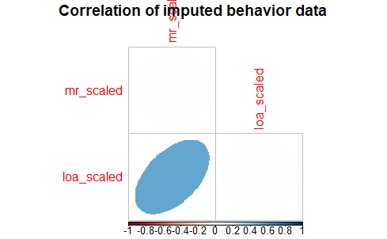

## 2.2 Scaling

```r
# scale numerical features
# df <- as.data.frame(scale(data))
# summary(df)
```

All features are scaled to mean=0, standard deviation=1.

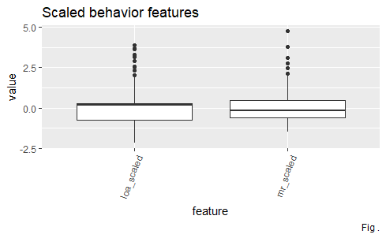

# 2. Hierachitcal clustering

Get distance matrix and hierarchical clustering using different linkages.

```r
dist.matrix <- dist(df, method = 'euclidean')

# hierarchical clustering
hc_avg <- hclust(dist.matrix, method = 'average') # average dissimilarities
hc_ward <- hclust(dist.matrix, method = 'ward.D2') # ward linkage
hc_complete <- hclust(dist.matrix, method = 'complete') # maximum linkage
hc_single <- hclust(dist.matrix, method = 'single') # minimum linkage
```

### Dendrograms

- Average linkage: pairwise dissimilarities, then take the average as distance
- Ward’s minimum variance method: minimize within-cluster variance
- Complete, or Maximum, linkage: pairwise dissimilarities then take the largest dissimilarity value as distance
- Single linkage: pairwise dissimilarities then take the smallest dissimilarity value as distance

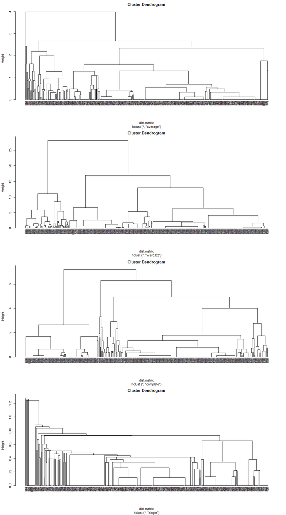

Which one to choose? Get the clustering coefficients using `agnes`:

```r
m <- c('average', 'ward', 'complete', 'single')
names(m) <- c('average', 'ward', 'complete', 'single')
ac <- function(x){cluster::agnes(df, method = x)$ac}
purrr::map_dbl(m, ac)
```

```
  average      ward  complete    single
0.9895944 0.9985000 0.9939496 0.9725943
```

**Ward’s minimum variance** method has the highest clustering coefficient, followed by **complete** method.

Take 4 clusters for example, look into Dendrograms from *ward* and *complete* methods:

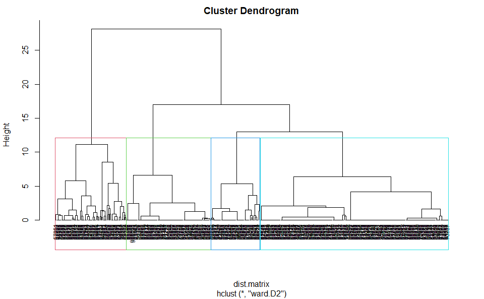

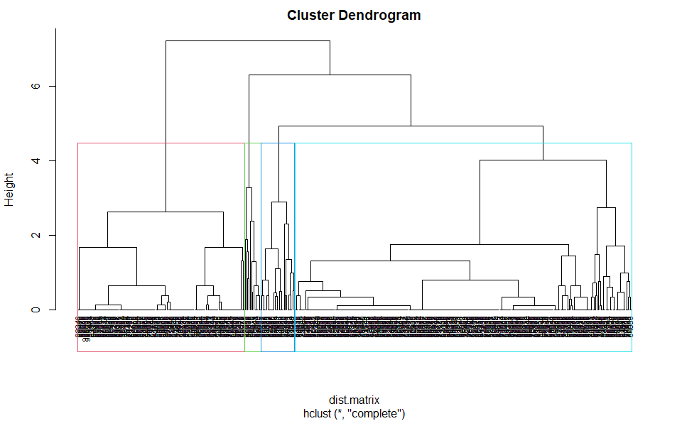

Next, will inspect the clustering results from these 2 methods.

### Visual inspection

Cut the dataframe to 2/3/4/5 clusters according to *ward*/*complete* methods, then compare the 8 results.

```r
set.seed(420)
# use cutree function
cut_ward.2 <- cutree(hc_ward, k=2)
cut_complete.2 <- cutree(hc_complete, k=2)
cut_ward.3 <- cutree(hc_ward, k=3)
cut_complete.3 <- cutree(hc_complete, k=3)
cut_ward.4 <- cutree(hc_ward, k=4)
cut_complete.4 <- cutree(hc_complete, k=4)
cut_ward.5 <- cutree(hc_ward, k=5)
cut_complete.5 <- cutree(hc_complete, k=5)

# store/map the clustering result to a new column 'cluster'
df.hc.ward.2 <- mutate(df, cluster_hc=cut_ward.2)
df.hc.complete.2 <- mutate(df, cluster_hc=cut_complete.2)
df.hc.ward.3 <- mutate(df, cluster_hc=cut_ward.3)
df.hc.complete.3 <- mutate(df, cluster_hc=cut_complete.3)
df.hc.ward.4 <- mutate(df, cluster_hc=cut_ward.4)
df.hc.complete.4 <- mutate(df, cluster_hc=cut_complete.4)
df.hc.ward.5 <- mutate(df, cluster_hc=cut_ward.5)
df.hc.complete.5 <- mutate(df, cluster_hc=cut_complete.5)
```

```r
# count records of each cluster
count(df.hc.ward.4, cluster_hc)
```

[output not shown]

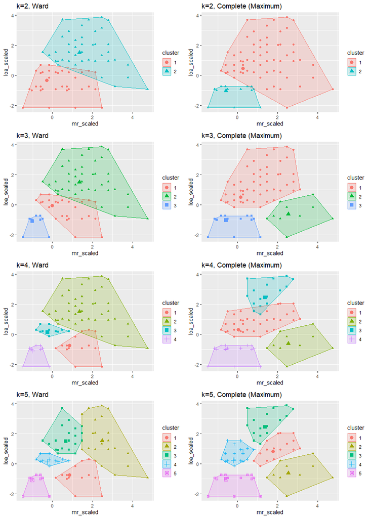

### Determine optimal clusters

3 methods

- Elbow method (by computing total within-cluster sum of square, WSS)
- Average silhouette method
- Gap statistic method (calculating the *gap* statistic, a goodness of clustering measure)

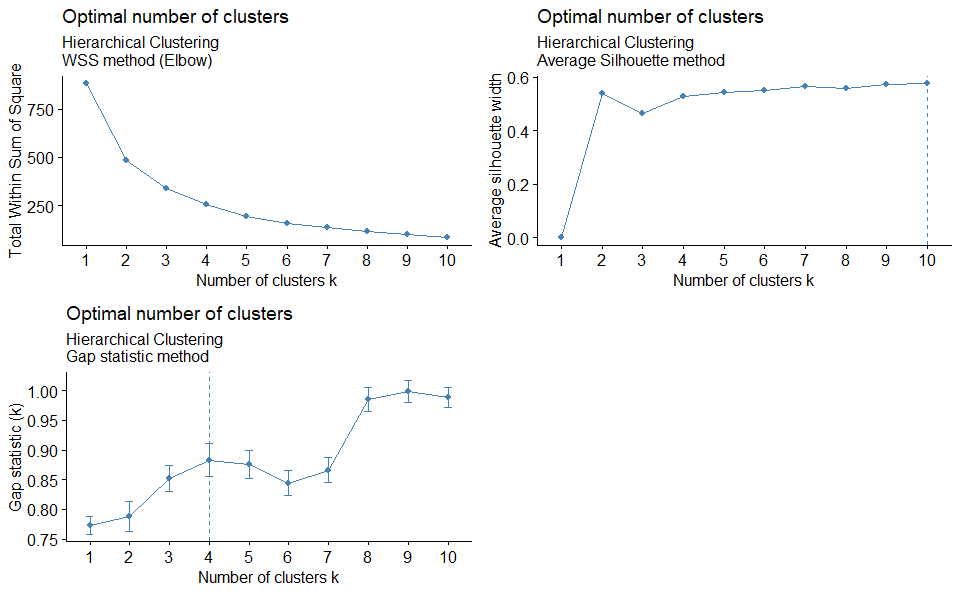

```r
set.seed(420)
# use fviz_nbclust wrapper
p1.hc <- fviz_nbclust(df, FUN=hcut, method='wss') +
  labs(subtitle = 'Hierarchical Clustering\nWSS method (Elbow)')
p2.hc <- fviz_nbclust(df, FUN=hcut, method = 'silhouette') +
  labs(subtitle = 'Hierarchical Clustering\nAverage Silhouette method')
p3.hc <- fviz_nbclust(df, FUN=hcut, method = 'gap_stat', verbose = FALSE) +
  labs(subtitle = 'Hierarchical Clustering\nGap statistic method')

# # plot gap_stat method again by specifying some parameters
# gap_stat.hc <- clusGap(df, FUN=hcut, K.max=8, B=500, verbose = FALSE)
# p4.hc <- fviz_gap_stat(gap_stat.hc) +
#   labs(subtitle='Hierarchical Clustering\nGap statistic method (manual)\n(bootstrap.sampling=500)')


gridExtra::grid.arrange(p1.hc,p2.hc,p3.hc, nrow=2)
```

k=4

## 2.4 K-Means

Crete 6 choices: number of cluster k=2,3,4,5,6,7

```r
set.seed(420)
# add 25 initial centroid configurations then average all centroids' results
ck.2 <- kmeans(df, centers = 2, nstart = 25)
ck.3 <- kmeans(df, centers = 3, nstart = 25)
ck.4 <- kmeans(df, centers = 4, nstart = 25)
ck.5 <- kmeans(df, centers = 5, nstart = 25)
ck.6 <- kmeans(df, centers = 6, nstart = 25)
ck.7 <- kmeans(df, centers = 7, nstart = 25)
```

### Visual inspection

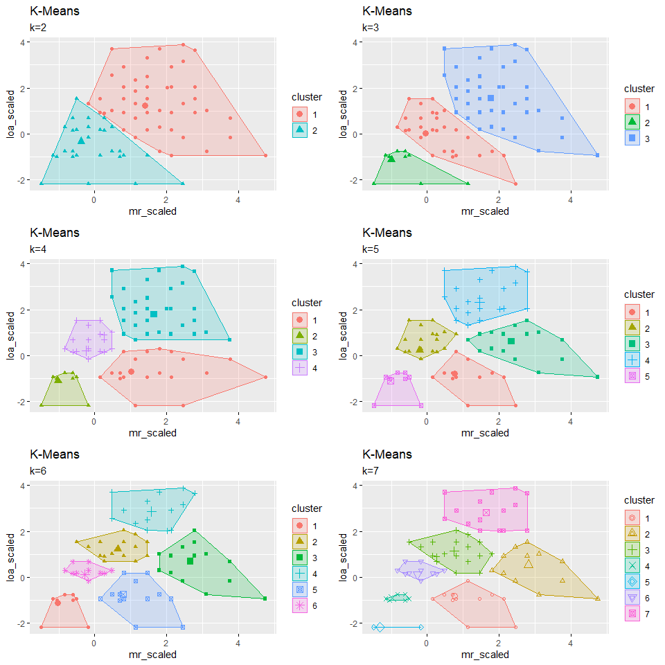

### Determine optimal clusters

3 methods

- Elbow method (calculating *WSS*)
- Average Silhouette method (the larger the better)
- Gap statistic method (calculating the *gap* statistic, a goodness of clustering measure)

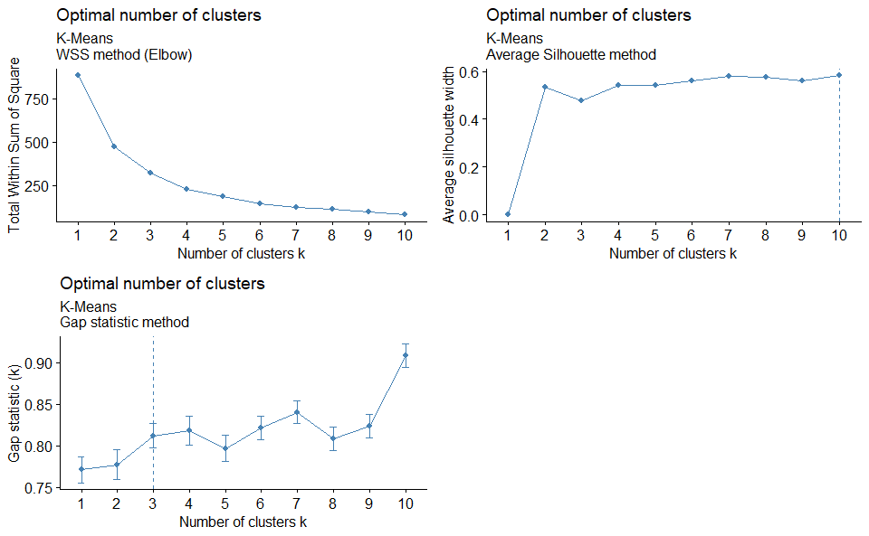

```r
set.seed(420)
# use fviz_nbclust wrapper
p1.km <- fviz_nbclust(df, nstart=25, FUN=kmeans, method='wss') +
  labs(subtitle = 'K-Means\nWSS method (Elbow)') # within-cluster sum of square
p2.km <- fviz_nbclust(df, nstart=25, FUN=kmeans, method = 'silhouette') +
  labs(subtitle = 'K-Means\nAverage Silhouette method')
p3.km <- fviz_nbclust(df, nstart=25, FUN=kmeans, method = 'gap_stat', verbose = FALSE ) +
  labs(subtitle='K-Means\nGap statistic method')

# # gap_stat manually, using clusGap{cluster}
# gap_stat.km <- clusGap(df, FUN=kmeans, nstart=25, K.max=8, B=300, verbose = FALSE)
# #print(gap_stat, method='firstmax')
# p4.km <- fviz_gap_stat(gap_stat.km) +
#   labs(subtitle='K-Means\nGap statistic method (manual)\n(nstart=25, bootstrap.sampling=300)')

gridExtra::grid.arrange(p1.km,p2.km,p3.km, nrow=2)
```

Detail of k=4

```r
ck.4
```

```
K-means clustering with 4 clusters of sizes 61, 95, 54, 231

Cluster means:
   mr_scaled loa_scaled
1  1.0113636 -0.6940866
2 -1.0242511 -1.1038466
3  1.6480146  1.7999172
4 -0.2310914  0.2164899

Clustering vector:
 81826  40709  84784  84655  61547  64718  68651  79930  45161  83344  66235  82698  83019  84664  81040  38905
     1      1      3      4      2      4      3      4      4      4      2      2      4      4      4      4
 83164  79005  67267  84613  85529  53988  82454  62786  57851  80666  69176  78606  54897  84531  62361  71202
     4      4      1      4      4      1      4      4      4      4      4      4      4      4      4      4
 81251  61728  79967  99995  81194  78695  68332  73145  37491  83308  71872  80882  84606  45797  59247  82418
```

[output cut: 60 more lines]

## 2.5 Extract results

Extract clustering result and map to data.

|  | mr_scaled | loa_scaled | cluster_km | cluster_hc |
| --- | --- | --- | --- | --- |
| 81826 | 1.1388601 | -0.154960 | 1 | 1 |
| 40709 | 3.7678012 | -0.154960 | 1 | 2 |
| 84784 | 1.1388601 | 2.337949 | 3 | 2 |
| 84655 | -0.1756105 | -0.154960 | 4 | 3 |
| 61547 | -1.4900810 | -2.171766 | 2 | 4 |
| 64718 | 0.4816248 | 1.017084 | 4 | 2 |

```r
# map back to behavior data
print(count(df, cluster_km))
```

| cluster_km | n |
| --- | --- |
| 1 | 61 |
| 2 | 95 |
| 3 | 54 |
| 4 | 231 |

Take cluster = 4, get the mean for each feature in each cluster, and distance between each center:

```r
# aggregate features by cluster, and return mean value
cluster.center = aggregate(df[1:2], list(cluster=cut_ward.4), mean)
dist.between.center <- dist(cluster.center[,-1])
print(list(cluster_center=cluster.center, dist_between_center=dist.between.center))
```

```
$cluster_center
  cluster  mr_scaled loa_scaled
1       1  0.8361335 -0.7406048
2       2  1.3373999  1.5080046
3       3 -0.2638648  0.1182859
4       4 -1.0242511 -1.1038466

$dist_between_center
         1        2        3
2 2.303804
3 1.395596 2.120228
4 1.895515 3.521244 1.439373
```

# 3. Merge results

Merge results and write to file